# A worked example of fitting Poseidon

Ernesto Carrella

January 13, 2017

## Osmose WFS

This is all work in progress but I wanted to show a worked example of how to go about and fitting a Poseidon instance to logbook data. Considers this a followup to the theoretical discussion [here](http://carrknight.github.io/poseidon/proposal.html).

Here I am going to use as biological layer the West-Florida Shelf parametrization of the OSMOSE model with a particular focus on red groupers. Most of the human data comes from Steve’s original thesis. This Poseidon implementation is still work in progress as a lot of inputs are missing but it’s mature enough that we can use it for data fitting. I do not have direct access to the logbook data but Steve has been kind enough to pass me logit fits which is all we need to fit poseidon to real data.

Logit fits are a very handy way to tease out factors driving fishing. Because they are discrete in nature, the first thing they require is to grid or split the map into separate areas. I can take that area division and add it straight to the model:

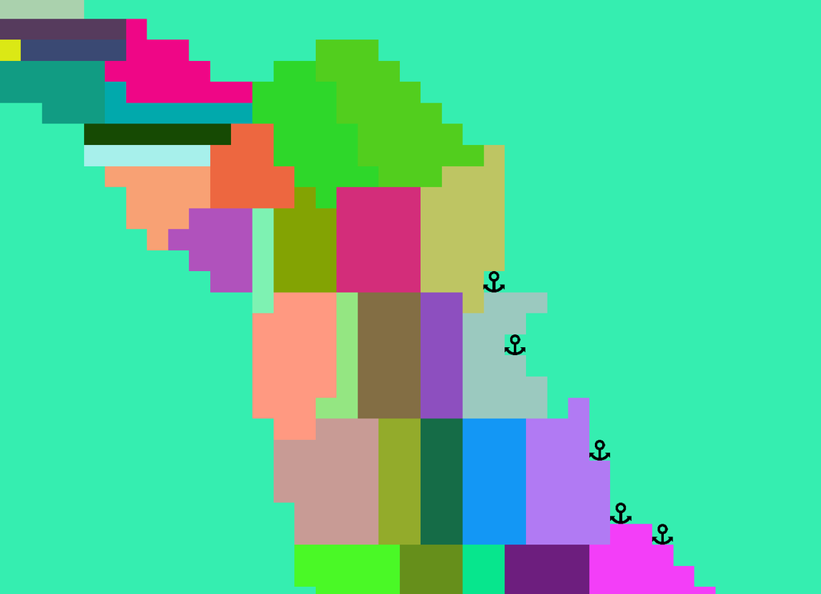

I can also force agents to read directly the logit regression and use it to make decision. These kind of agents are non-adaptive and they do not interact with OSMOSE much but their purpose is to generate synthetic logbook data:

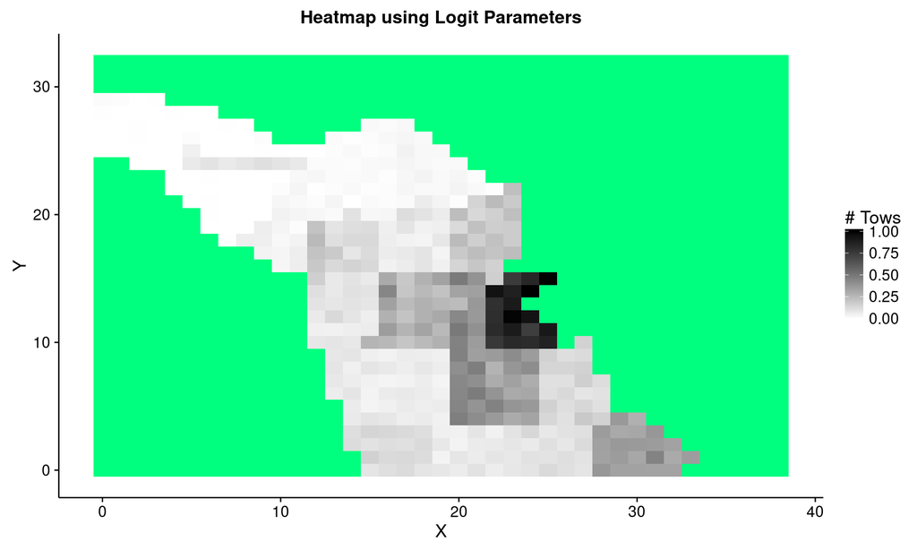

This we can consider our “target” heatmap. We run Poseidon with adapting agents fishing over OSMOSE WFS and look for the behavioural parameters that generate heatmaps as close as possible as the one above. Here’s an example:

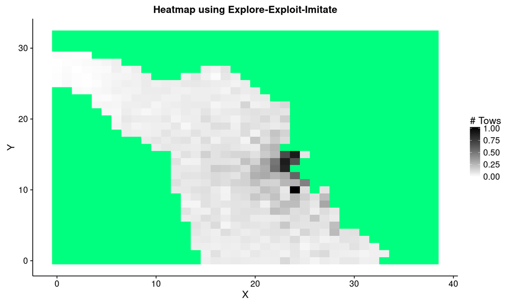

The main issue is how to measure the distance between two heatmaps. We can simplify it a little bit by counting frequency by logit-area. At which point what we are really doing is the distance between histograms:

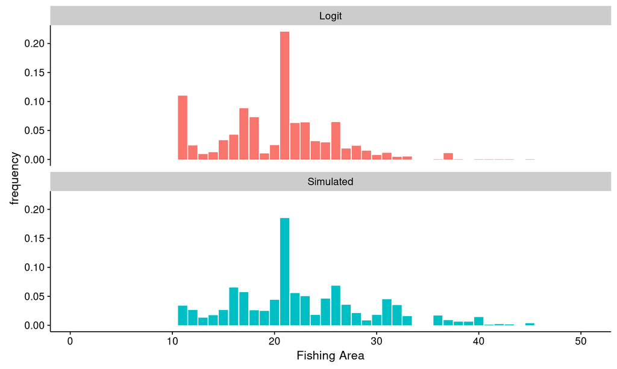

An obvious, although suboptimal, way to measure distance is simply sum squared difference of frequencies. We can then intruct the optimizer to look for the behavioural parametres that minimize the histogram distance.

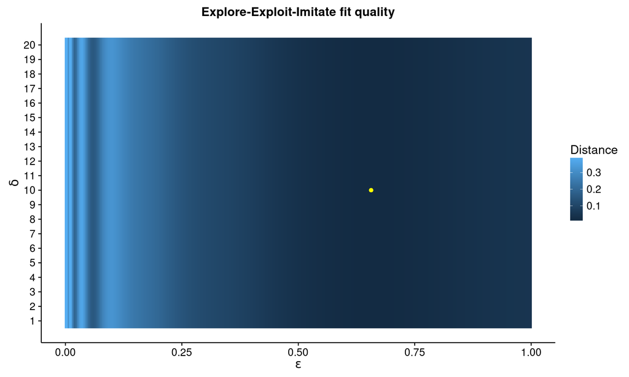

So for this particular example we have that the best fitting parameters are $\epsilon = 0.656$ and $'delta = 10$.

## What’s next?

Histogram distance is nice but indirect inference would be better (as it is far more informative). The idea is that we compute the distance between the original logit parameters and the parameters we obtain by running the same logit regression on a simulated logbook.

Each regression generates a table of parameters like this:

| names | x |
| --- | --- |
| 1:(intercept) | -1.0004042 |
| 2:(intercept) | -1.7178112 |
| 3:(intercept) | -1.4156111 |
| 4:(intercept) | -0.4964323 |
| 5:(intercept) | -1.0770913 |
| 6:(intercept) | -0.6052483 |
| 7:(intercept) | -0.6590327 |
| 8:(intercept) | -1.9700377 |
| 9:(intercept) | -1.0810381 |
| 10:(intercept) | -0.5397890 |
| 11:(intercept) | -1.1428262 |
| 12:(intercept) | -0.9065180 |
| 13:(intercept) | -1.1879723 |
| 14:(intercept) | -1.0240187 |
| 15:(intercept) | -0.8670492 |
| 16:(intercept) | -1.5483634 |
| 17:(intercept) | -1.0845654 |
| 18:(intercept) | -1.2947422 |
| 19:(intercept) | -1.6615917 |
| 20:(intercept) | -1.4872624 |
| 21:(intercept) | -2.1604439 |
| 22:(intercept) | -1.9899246 |
| 23:(intercept) | -4.0227858 |
| 24:(intercept) | -0.8158933 |
| 25:(intercept) | -2.9571875 |
| distance | -0.0056309 |
| habit | 2.1452945 |

All we need to do is to minimize the sum of squared differences between parameters weighted by their standard error. Something I hope to do next.